# Student Quality Checks before binding

The Freemasons

Initiated on 2019 Dec 13, compiled on 2020 May 24

# 1 Loading package

```r
library(tidyverse)
library(glue)
library(here)
```

# 2 Loading data

```r
## Reading in the all student data as tibbles and make sure all variables are coded in the correct variable type
dfs_stu_qqq <- tibble(years = seq(2000, 2018, 3)) %>%
  mutate(paths = glue("Data/Output/{years}/{what}.rds", what = "stu_qqq")) %>%
  mutate(data = map(.x = paths,
                    .f = ~ .x %>%
                      here() %>%
                      read_rds() %>%
                      mutate(school_id = as.character(school_id),
                             student_id = as.character(student_id)) %>%
                      mutate_at(c("mother_educ", "father_educ",
                                  "gender", "computer", "internet",
                                  "desk", "room", "dishwasher", "television",
                                  "computer_n", "car", "book"),
                                as.integer) %>%
                      mutate_at(c("math", "science", "read",
                                  "stu_wgt", "wealth", "escs"),
                                as.numeric)))

names(dfs_stu_qqq$data) <- seq(2000, 2018, 3)
student <- bind_rows(dfs_stu_qqq$data, .id = "year")
student %>%
  group_by(year) %>%
  sample_n(2)
```

```
## # A tibble: 14 x 22
## # Groups:   year [7]
##    year  country_iso3c school_id student_id mother_educ father_educ gender
##    <chr> <chr>         <chr>     <chr>            <int>       <int>  <int>
##  1 2000  IRL           3070      2456                NA          NA      2
##  2 2000  POL           2078      2034                NA          NA      1
##  3 2003  GBR           00149     03626                4           4      2
##  4 2003  IDN           00298     09298                5           5      1
##  5 2006  AZE           70        2068                 1           1      2
##  6 2006  THA           2089      16                   3           3      1
##  7 2009  ESP           00623     18207                1           1      1
##  8 2009  MAC           00013     01768                3           4      1
##  9 2012  SGP           0000070   02281                4           1      2
## 10 2012  ARE           0000320   08129                1           1      2
## 11 2015  QCH           97000258  97000990             1           1      2
## 12 2015  CHL           15200002  15201288             1           1      1
## 13 2018  KAZ           39800004  39810231             1           3      1
## 14 2018  KOR           41000109  41003615             1           1      2
## # … with 15 more variables: computer <int>, internet <int>, math <dbl>,
## #   read <dbl>, science <dbl>, stu_wgt <dbl>, desk <int>, room <int>,
## #   dishwasher <int>, television <int>, computer_n <int>, car <int>,
## #   book <int>, wealth <dbl>, escs <dbl>
```

```r
load(here("Data/Output/countrycode.rda"))

student = student %>%
  mutate(year = as.integer(year),
         country = as.factor(country_iso3c),
         student_id = as.factor(student_id),
         school_id = as.factor(school_id),
         gender = as.factor(gender)) %>%
  dplyr::select(-country_iso3c) ## We will use the 3-character codes as the only identifier (factor)
```

# 3 Quality check for each variable

We will use `janitor::tabyl` for it has a better print method and always includes NA

## 3.1 Skim through data

```r
library(skimr)
colnames(student)
```

```
##  [1] "year"        "school_id"   "student_id"  "mother_educ" "father_educ"
##  [6] "gender"      "computer"    "internet"    "math"        "read"
## [11] "science"     "stu_wgt"     "desk"        "room"        "dishwasher"
## [16] "television"  "computer_n"  "car"         "book"        "wealth"
## [21] "escs"        "country"
```

```r
skimr::skim(student)
```

Data summary

| Name | student |
| --- | --- |
| Number of rows | 2929621 |
| Number of columns | 22 |
| _______________________ |  |
| Column type frequency: |  |
| factor | 4 |
| numeric | 18 |
| ________________________ |  |
| Group variables | None |

**Variable type: factor**

| skim_variable | n_missing | complete_rate | ordered | n_unique | top_counts |
| --- | --- | --- | --- | --- | --- |
| school_id | 0 | 1 | FALSE | 33499 | 000: 4041, 000: 3929, 000: 3799, 000: 3788 |
| student_id | 0 | 1 | FALSE | 849620 | 1: 814, 3: 805, 6: 803, 5: 802 |
| gender | 1702 | 1 | FALSE | 3 | 1: 1472901, 2: 1455012, 9: 6 |
| country | 0 | 1 | FALSE | 100 | CAN: 154549, MEX: 150425, ESP: 127731, ITA: 121524 |

**Variable type: numeric**

| skim_variable | n_missing | complete_rate | mean | sd | p0 | p25 | p50 | p75 | p100 | hist |
| --- | --- | --- | --- | --- | --- | --- | --- | --- | --- | --- |
| year | 0 | 1.00 | 2011.07 | 5.35 | 2000.00 | 2006.00 | 2012.00 | 2015.00 | 2018.00 | ▃▃▃▃▇ |
| mother_educ | 199437 | 0.93 | 2.31 | 1.67 | 1.00 | 1.00 | 2.00 | 3.00 | 9.00 | ▇▃▁▁▁ |
| father_educ | 227376 | 0.92 | 2.44 | 1.82 | 1.00 | 1.00 | 2.00 | 3.00 | 9.00 | ▇▃▁▁▁ |
| computer | 170981 | 0.94 | 1.27 | 0.86 | 1.00 | 1.00 | 1.00 | 1.00 | 9.00 | ▇▁▁▁▁ |
| internet | 47118 | 0.98 | 1.31 | 0.90 | 1.00 | 1.00 | 1.00 | 1.00 | 9.00 | ▇▁▁▁▁ |
| math | 81368 | 0.97 | 466.82 | 104.88 | -53.45 | 392.77 | 466.42 | 540.76 | 1022.21 | ▁▂▇▂▁ |
| read | 41320 | 0.99 | 483.64 | 432.97 | -79.04 | 392.71 | 469.15 | 541.88 | 9997.00 | ▇▁▁▁▁ |
| science | 5377 | 1.00 | 470.87 | 104.08 | -169.93 | 396.25 | 470.08 | 545.23 | 940.31 | ▁▁▇▆▁ |
| stu_wgt | 0 | 1.00 | 56.24 | 130.47 | 1.00 | 5.94 | 15.12 | 46.52 | 6945.81 | ▇▁▁▁▁ |
| desk | 47368 | 0.98 | 1.20 | 0.82 | 1.00 | 1.00 | 1.00 | 1.00 | 9.00 | ▇▁▁▁▁ |
| room | 55969 | 0.98 | 1.28 | 0.84 | 1.00 | 1.00 | 1.00 | 1.00 | 9.00 | ▇▁▁▁▁ |
| dishwasher | 1150988 | 0.61 | 1.67 | 1.25 | 1.00 | 1.00 | 1.00 | 2.00 | 9.00 | ▇▁▁▁▁ |
| television | 317220 | 0.89 | 3.18 | 0.95 | 1.00 | 3.00 | 3.00 | 4.00 | 9.00 | ▃▇▁▁▁ |
| computer_n | 320889 | 0.89 | 2.67 | 1.22 | 1.00 | 2.00 | 3.00 | 4.00 | 9.00 | ▇▇▁▁▁ |
| car | 345403 | 0.88 | 2.47 | 1.21 | 1.00 | 2.00 | 2.00 | 3.00 | 9.00 | ▇▆▁▁▁ |
| book | 48179 | 0.98 | 3.10 | 1.57 | 1.00 | 2.00 | 3.00 | 4.00 | 9.00 | ▇▇▂▂▁ |
| wealth | 307704 | 0.89 | 38.90 | 618.07 | -7.64 | -1.11 | -0.33 | 0.37 | 9999.00 | ▇▁▁▁▁ |
| escs | 41852 | 0.99 | 63.40 | 787.58 | -8.17 | -0.97 | -0.17 | 0.61 | 9999.00 | ▇▁▁▁▁ |

## 3.2 `year`

This looks ok, though you can see how the survey was expanded in the later years.

```r
library(janitor)
student %>%
  tabyl(year)
```

```
##  year      n    percent
##  2000 127236 0.04343087
##  2003 276165 0.09426646
##  2006 398750 0.13610976
##  2009 515958 0.17611766
##  2012 480174 0.16390311
##  2015 519334 0.17727003
##  2018 612004 0.20890211
```

## 3.3 country

This looks ok.

```r
student %>%
  tabyl(country)
```

```
##  country      n      percent
##      ALB  23685 0.0080846635
##      ARE  55811 0.0190505871
##      ARG  29207 0.0099695490
##      AUS  87116 0.0297362696
##      AUT  37347 0.0127480654
##      AZE   9875 0.0033707432
##      BEL  56599 0.0193195639
##      BGR  28055 0.0095763240
##      BIH   6480 0.0022118902
##      BLR   5803 0.0019808023
##      BRA  89620 0.0305909877
##      BRN   6828 0.0023306769
##      CAN 154549 0.0527539228
##      CHE  58732 0.0200476444
##      CHL  35143 0.0119957496
##      COL  40789 0.0139229614
##      CRI  23267 0.0079419829
##      CZE  40618 0.0138645920
##      DEU  34341 0.0117219941
##      DNK  39319 0.0134211900
##      DOM  10414 0.0035547260
##      DZA   5519 0.0018838614
##      ESP 127731 0.0435998377
##      EST  25274 0.0086270545
##      FIN  39390 0.0134454252
##      FRA  32935 0.0112420685
##      GBR  80679 0.0275390571
##      GEO  15534 0.0053023924
##      GRC  34122 0.0116472404
##      HKG  32463 0.0110809555
##      HRV  27633 0.0094322781
##      HUN  32260 0.0110116633
##      IDN  54853 0.0187235823
##      IRL  30870 0.0105371992
##      ISL  22819 0.0077890621
##      ISR  31135 0.0106276546
##      ITA 121524 0.0414811336
##      JOR  36263 0.0123780516
##      JPN  38768 0.0132331110
```

[output cut: 46 more lines]

```
##      SGP  23620 0.0080624763
##      SRB  21614 0.0073777461
##      SVK  33625 0.0114775939
##      SVN  31468 0.0107413211
##      SWE  31776 0.0108464542
##      TAP  35643 0.0121664202
##      THA  44106 0.0150551897
##      TTO   9470 0.0032325000
##      TUN  24098 0.0082256374
##      TUR  32426 0.0110683259
##      UKR   5998 0.0020473638
##      URY  33271 0.0113567591
##      USA  33957 0.0115909191
##      VNM  16162 0.0055167546
##      YUG   4405 0.0015036075
```

## 3.4 School id

This looks ok. Though we can see that a school_id is only unique given a year country combination. So we can’t track a school’s performance over the years.

```r
student %>%
  tabyl(school_id) %>%
  head
```

```
##  school_id    n      percent
##    0000001 1935 0.0006604950
##    0000002 2090 0.0007134029
##    0000003 2136 0.0007291045
##    0000004 2024 0.0006908743
##    0000005 2071 0.0007069174
##    0000006 1923 0.0006563989
```

```r
student %>%
  filter(school_id == "1") %>%
  tabyl(country, year) %>% head(20)
```

```
##  country 2000 2006
##      ALB    0    0
##      ARE    0    0
##      ARG    0   34
##      AUS    0   41
##      AUT   19   29
##      AZE    0   35
##      BEL    0   75
##      BGR    0    4
##      BIH    0    0
##      BLR    0    0
##      BRA    0    3
##      BRN    0    0
##      CAN    2   26
##      CHE    0   33
##      CHL    0   35
##      COL    0   34
##      CRI    0    0
##      CZE    0    5
##      DEU    0   25
##      DNK    0   21
```

## 3.5 mother_educ

It looks like encoding for this variable changed throughout the survey. + KW can confirm (through provided script in https://github.com/gvdr/learningtower_masonry/blob/master/Code/2000/student2000.R) that this variable is missing in the 2000 survey.

```r
student %>%
  tabyl(year, mother_educ)
```

```
##  year      1      2      3     4      5    7    8     9    NA_
##  2000      0      0      0     0      0    0    0     0 127236
##  2003  16093  32168  48433 40243 125014    0    0     0  14214
##  2006 180629  72633  72267 35273  18139 2015 3289 14505      0
##  2009 236671  91964  88647 46570  23124 3214 9336 16432      0
##  2012 232322  83048  82288 36480  18709 3635 8979 14713      0
##  2015 252137  92688  89423 35081  17285    0    0     0  32720
##  2018 319865 113304 100956 34557  18055    0    0     0  25267
```

## 3.6 father_educ

It looks like encoding for this variable changed throughout the survey. + KW can confirm (through provided script in https://github.com/gvdr/learningtower_masonry/blob/master/Code/2000/student2000.R) that this variable is missing in the 2000 survey.

```r
student %>%
  tabyl(year, father_educ)
```

```
##  year      1      2      3     4      5    7    8     9    NA_
##  2000      0      0      0     0      0    0    0     0 127236
##  2003  12934  29400  48649 44661 117410    0    0     0  23111
##  2006 168658  80309  70193 33275  15378 2037 3705 25195      0
##  2009 219216 101843  88483 44578  19840 3184 8585 30229      0
##  2012 210986  91179  83920 35840  16480 3656 9466 28647      0
##  2015 231012 104282  90006 36172  16747    0    0     0  41115
##  2018 291768 130423 100865 35046  17988    0    0     0  35914
```

## 3.7 gender

It looks like there are inconsistent coding for NA. Needs to double check this on individual year levels.

```r
student %>%
  tabyl(year, gender)
```

```
##  year      1      2 9 NA_
##  2000  64057  62275 0 904
##  2003 138811 136558 0 796
##  2006 201478 197268 4   0
##  2009 260977 254979 2   0
##  2012 242375 237799 0   0
##  2015 260245 259089 0   0
##  2018 304958 307044 0   2
```

## 3.8 computer

It looks like there are inconsistent coding for NA. Needs to double check this on individual year levels.

```r
student %>%
  tabyl(year, computer)
```

```
##  year      1      2    7   8    9    NA_
##  2000      0      0    0   0    0 127236
##  2003 188172  84911    0   0    0   3082
##  2006 297247  92950 1848 286 6419      0
##  2009 403428 101579 2969 392 7590      0
##  2012 406141  62507 3623 364 7539      0
##  2015 426698  71943    0   0    0  20693
##  2018 486324 105710    0   0    0  19970
```

## 3.9 internet

It looks like there are inconsistent coding for NA. Needs to double check this on individual year levels.

```r
student %>%
  tabyl(year, internet)
```

```
##  year      1      2    7   8    9   NA_
##  2000  49692  73609    0   0    0  3935
##  2003 150692 122397    0   0    0  3076
##  2006 252233 136095 1845 259 8318     0
##  2009 371600 132238 2968 359 8793     0
##  2012 397066  70899 3656 350 8203     0
##  2015 446149  52369    0   0    0 20816
##  2018 543010  49703    0   0    0 19291
```

## 3.10 math

It looks like there are lot more missing values in the 2000 data and a small amount in 2018. Otherwise all other years are complete.

```r
library(ggridges)

student %>%
  group_by(year, is.na(math)) %>%
  tally()
```

```
## # A tibble: 9 x 3
## # Groups:   year [7]
##    year `is.na(math)`      n
##   <int> <lgl>          <int>
## 1  2000 FALSE          51245
## 2  2000 TRUE           75991
## 3  2003 FALSE         276165
## 4  2006 FALSE         398750
## 5  2009 FALSE         515958
## 6  2012 FALSE         480174
## 7  2015 FALSE         519334
## 8  2018 FALSE         606627
## 9  2018 TRUE            5377
```

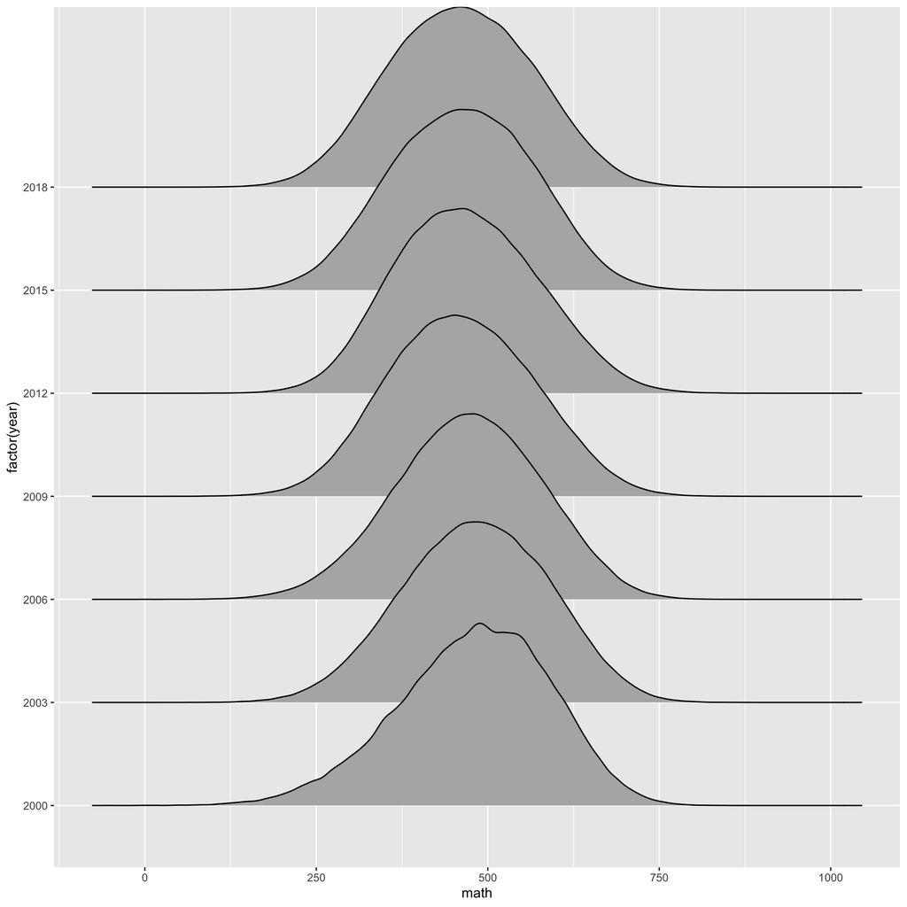

```r
student %>%
  ggplot(aes(x = math, y = factor(year))) +
  geom_density_ridges()
```

## 3.11 read

It looks like there are lot more missing values in the 2018 data. Otherwise all other years are complete.

2006 also contains outliers (9997) that should be removed/recoded. This coding is likely an error code.

```r
student %>%
  group_by(year, is.na(read)) %>%
  tally()
```

```
## # A tibble: 8 x 3
## # Groups:   year [7]
##    year `is.na(read)`      n
##   <int> <lgl>          <int>
## 1  2000 FALSE         127236
## 2  2003 FALSE         276165
## 3  2006 FALSE         398750
## 4  2009 FALSE         515958
## 5  2012 FALSE         480174
## 6  2015 FALSE         519334
## 7  2018 FALSE         570684
## 8  2018 TRUE           41320
```

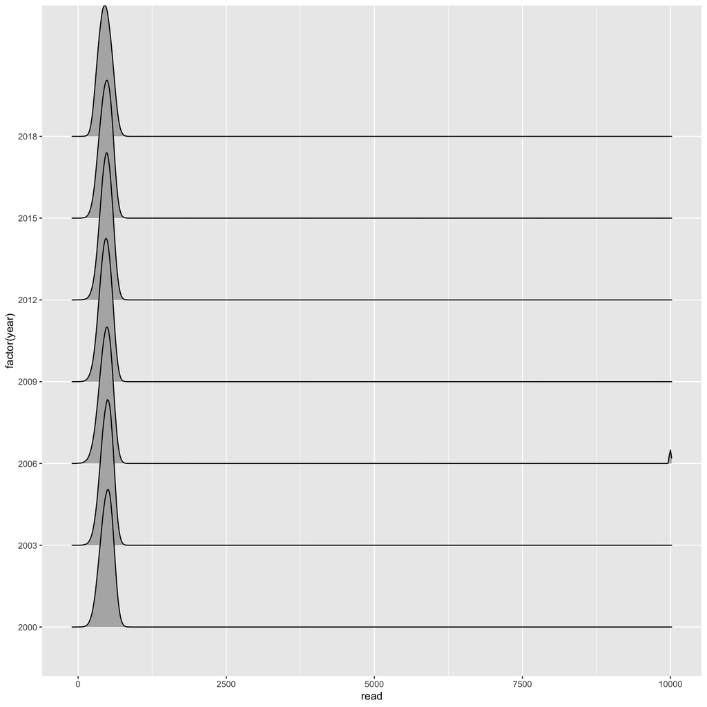

```r
student %>%
  ggplot(aes(x = read, y = factor(year))) +
  geom_density_ridges()
```

```r
student %>%
  dplyr::filter(read > 1000) %>%
  group_by(year, read) %>%
  tally()
```

```
## # A tibble: 3 x 3
## # Groups:   year [1]
##    year  read     n
##   <int> <dbl> <int>
## 1  2006 1079.     1
## 2  2006 1084.     3
## 3  2006 9997   5611
```

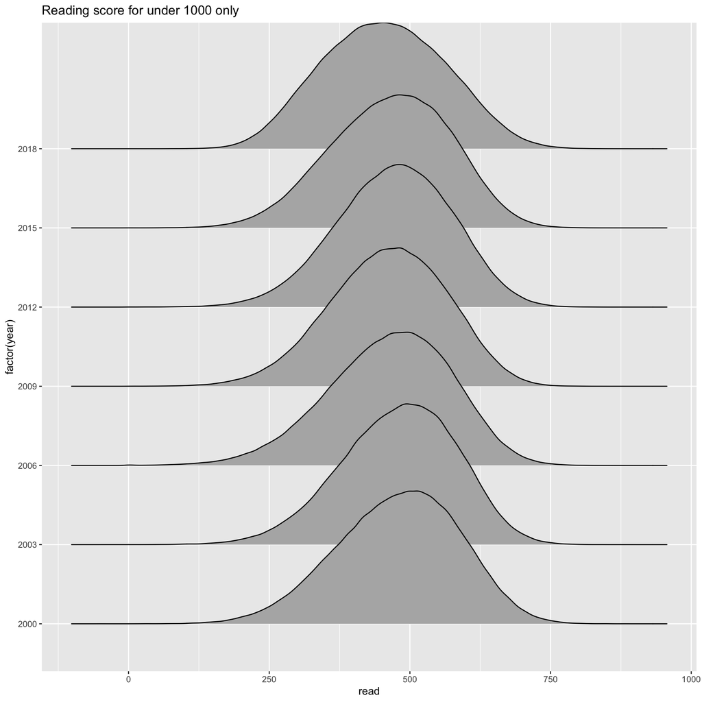

```r
student %>%
  dplyr::filter(read < 1000) %>%
  ggplot(aes(x = read, y = factor(year))) +
  geom_density_ridges() +
  labs(title = "Reading score for under 1000 only")
```

## 3.12 science

It looks like there are lot more missing values in the 2018 data. Otherwise all other years are complete.

```r
student %>%
  group_by(year, is.na(science)) %>%
  tally()
```

```
## # A tibble: 8 x 3
## # Groups:   year [7]
##    year `is.na(science)`      n
##   <int> <lgl>             <int>
## 1  2000 FALSE            127236
## 2  2003 FALSE            276165
## 3  2006 FALSE            398750
## 4  2009 FALSE            515958
## 5  2012 FALSE            480174
## 6  2015 FALSE            519334
## 7  2018 FALSE            606627
## 8  2018 TRUE               5377
```

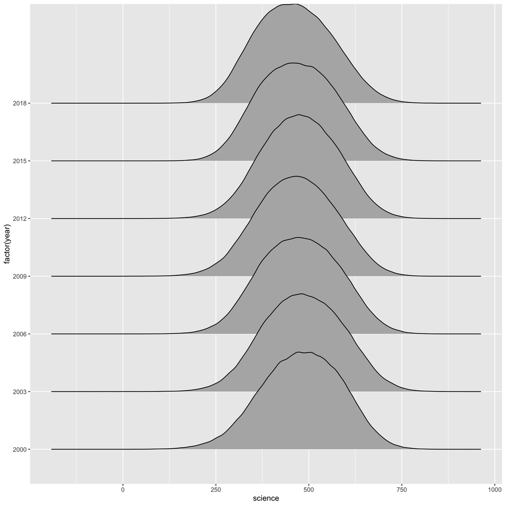

```r
student %>%
  ggplot(aes(x = science, y = factor(year))) +
  geom_density_ridges()
```

## 3.13 stu_wgt

Not sure how to judge this variable. This is highly right-skewed, but these values are also plausible observed/computed values.

```r
student %>%
  group_by(year, is.na(stu_wgt)) %>%
  tally()
```

```
## # A tibble: 7 x 3
## # Groups:   year [7]
##    year `is.na(stu_wgt)`      n
##   <int> <lgl>             <int>
## 1  2000 FALSE            127236
## 2  2003 FALSE            276165
## 3  2006 FALSE            398750
## 4  2009 FALSE            515958
## 5  2012 FALSE            480174
## 6  2015 FALSE            519334
## 7  2018 FALSE            612004
```

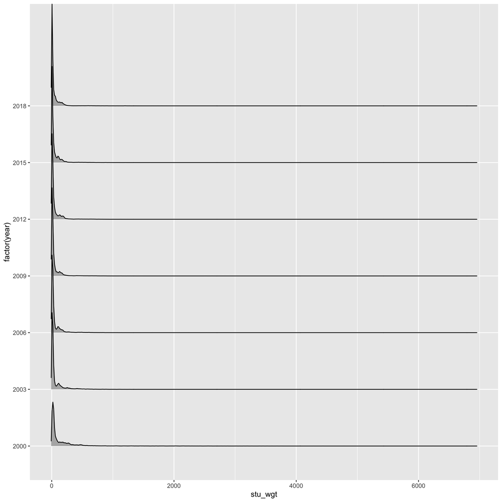

```r
student %>%
  ggplot(aes(x = stu_wgt, y = factor(year))) +
  geom_density_ridges()
```

```r
student %>%
  dplyr::filter(stu_wgt > 1000) %>%
  group_by(year, stu_wgt) %>%
  tally()
```

```
## # A tibble: 744 x 3
## # Groups:   year [7]
##     year stu_wgt     n
##    <int>   <dbl> <int>
##  1  2000   1001.     7
##  2  2000   1004.    11
##  3  2000   1007.    10
##  4  2000   1007.    10
##  5  2000   1011.     3
##  6  2000   1014.     9
##  7  2000   1015.     7
##  8  2000   1018.    11
##  9  2000   1018.     7
## 10  2000   1018.     7
## # … with 734 more rows
```

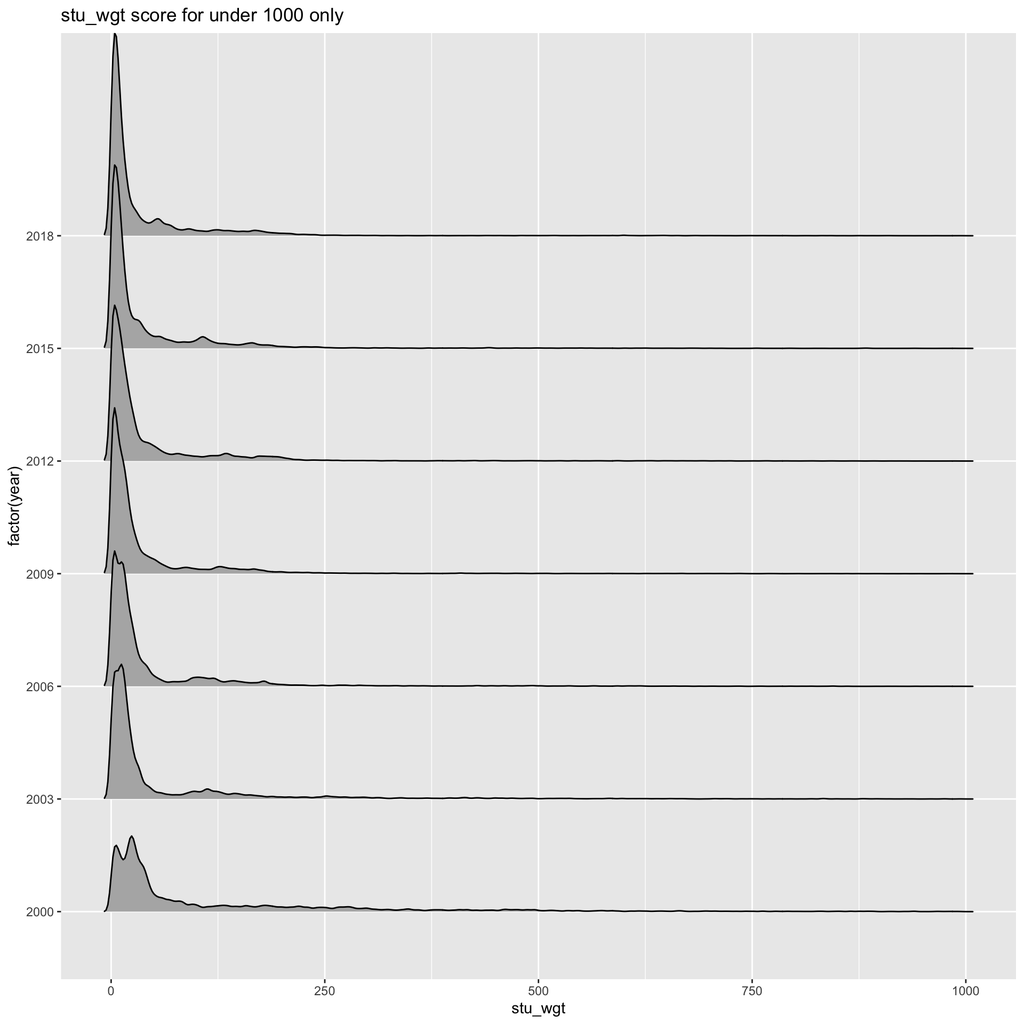

```r
student %>%
  dplyr::filter(stu_wgt < 1000) %>%
  ggplot(aes(x = stu_wgt, y = factor(year))) +
  geom_density_ridges() +
  labs(title = "stu_wgt score for under 1000 only")
```

## 3.14 desk

It looks like there are inconsistent coding for NA. Needs to double check this on individual year levels.

```r
student %>%
  tabyl(year, desk)
```

```
##  year      1     2    7   8    9   NA_
##  2000 108155 16112    0   0    0  2969
##  2003 235626 37462    0   0    0  3077
##  2006 348642 42620 1847 220 5421     0
##  2009 445721 59369 2968 285 7615     0
##  2012 414837 53054 3621 225 8437     0
##  2015 439620 58391    0   0    0 21323
##  2018 523492 68513    0   0    0 19999
```

## 3.15 room

It looks like there are inconsistent coding for NA. Needs to double check this on individual year levels.

```r
student %>%
  tabyl(year, room)
```

```
##  year      1      2    7   8    9   NA_
##  2000  98475  25959    0   0    0  2802
##  2003 214620  58469    0   0    0  3076
##  2006 308437  83383 1846 262 4822     0
##  2009 392742 113605 2967 365 6279     0
##  2012 367594  96857 8539 309 6875     0
##  2015 404342  89484    0   0    0 25508
##  2018 478520 108901    0   0    0 24583
```

## 3.16 dishwasher

It looks like there are inconsistent coding for NA. Needs to double check this on individual year levels.

```r
student %>%
  tabyl(year, dishwasher)
```

```
##  year      1      2     7   8     9    NA_
##  2000  57201  64227     0   0     0   5808
##  2003 128918 133405     0   0     0  13842
##  2006 191509 185656 12494 384  8707      0
##  2009 264060 237792  2968 510 10628      0
##  2012 266532 197389  3623 522 12108      0
##  2015      0      0     0   0     0 519334
##  2018      0      0     0   0     0 612004
```

## 3.17 television

It looks like there are inconsistent coding for NA. Needs to double check this on individual year levels.

```r
student %>%
  tabyl(year, television)
```

```
##  year     1      2      3      4    7   8    9    NA_
##  2000  3008  28636  44556  47818    0   0    0   3218
##  2003     0      0      0      0    0   0    0 276165
##  2006  5686  88246 135564 163764 1844 801 2845      0
##  2009  8249 115537 173051 211189 2976 964 3992      0
##  2012  6800 100059 162184 202268 3664 708 4491      0
##  2015  7734 116265 166100 210469    0   0    0  18766
##  2018 11304 158958 199649 223022    0   0    0  19071
```

## 3.18 computer_n

It looks like there are inconsistent coding for NA. Needs to double check this on individual year levels.

```r
student %>%
  tabyl(year, computer_n)
```

```
##  year     1      2      3      4    7    8    9    NA_
##  2000 44809  53448  17360   7150    0    0    0   4469
##  2003     0      0      0      0    0    0    0 276165
##  2006 85894 180612  76418  46192 1852 1196 6586      0
##  2009 94125 190786 118395 100412 2970 1251 8019      0
##  2012 52142 139147 129238 147712 3627  802 7506      0
##  2015 53598 137024 140453 167528    0    0    0  20731
##  2018 74357 176453 164784 176886    0    0    0  19524
```

## 3.19 car

It looks like there are inconsistent coding for NA. Needs to double check this on individual year levels.

```r
student %>%
  tabyl(year, car)
```

```
##  year      1      2      3     4    7   8    9    NA_
##  2000  27294  45775  34561 15462    0   0    0   4144
##  2003      0      0      0     0    0   0    0 276165
##  2006  82700 138773 114276 53178 1841 927 7055      0
##  2009 119977 170213 141221 71512 2968 827 9240      0
##  2012  98101 160232 140259 68695 3627 616 8644      0
##  2015  94368 167982 151990 77494    0   0    0  27500
##  2018 108424 197311 173190 95485    0   0    0  37594
```

## 3.20 book

It looks like there are inconsistent coding for NA. Needs to double check this on individual year levels.

```r
student %>%
  tabyl(year, book)
```

```
##  year      1      2      3     4     5     6     7    8    9   NA_
##  2000   2525  14544  26809 25029 23488 16881 12888    0    0  5072
##  2003  36349  46363  78959 46765 36080 22234     0    0    0  9415
##  2006  61332  74769 116401 63613 47097 27567  1890 1587 4494     0
##  2009  90966 104844 148102 75412 53594 32175  2972 2099 5794     0
##  2012  94016  96371 133686 67538 48633 28293  3630 1453 6554     0
##  2015  98694 100067 141559 74652 54610 31706     0    0    0 18046
##  2018 125583 124194 169222 84750 59168 33441     0    0    0 15646
```

## 3.21 wealth

Outliers (997, 999, 9997, 9999) that should be removed/recoded. These codings are likely an error codes.

The distribution is also weirdly smooth in 2018 but discretised in 2000.

```r
student %>%
  group_by(year, is.na(wealth)) %>%
  tally()
```

```
## # A tibble: 10 x 3
## # Groups:   year [7]
##     year `is.na(wealth)`      n
##    <int> <lgl>            <int>
##  1  2000 FALSE           125164
##  2  2000 TRUE              2072
##  3  2003 TRUE            276165
##  4  2006 FALSE           398750
##  5  2009 FALSE           515958
##  6  2012 FALSE           480174
##  7  2015 FALSE           503604
##  8  2015 TRUE             15730
##  9  2018 FALSE           598267
## 10  2018 TRUE             13737
```

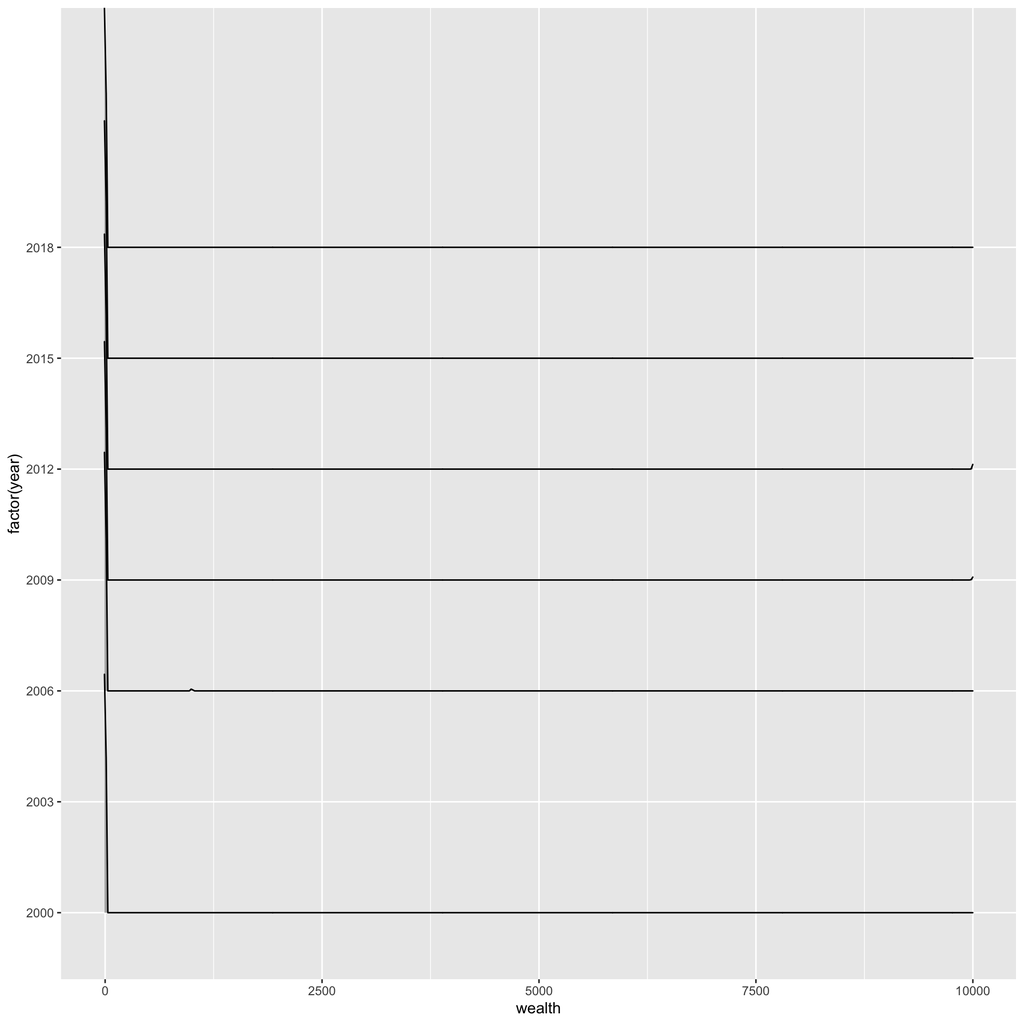

```r
student %>%
  ggplot(aes(x = wealth, y = factor(year))) +
  geom_density_ridges()
```

```r
student %>%
  dplyr::filter(wealth > 5) %>%
  group_by(year, wealth) %>%
  tally()
```

```
## # A tibble: 5 x 3
## # Groups:   year [3]
##    year wealth     n
##   <int>  <dbl> <int>
## 1  2006    997  1802
## 2  2006    999   969
## 3  2009   9997  2427
## 4  2009   9999  1730
## 5  2012   9999  5874
```

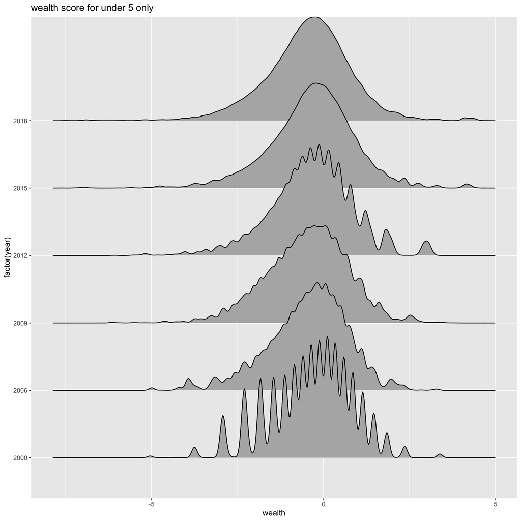

```r
student %>%
  dplyr::filter(wealth < 5) %>%
  ggplot(aes(x = wealth, y = factor(year))) +
  geom_density_ridges() +
  labs(title = "wealth score for under 5 only")
```

## 3.22 escs

Outliers (997, 999, 9997, 9999) that should be removed/recoded. These codings are likely an error codes.

```r
student %>%
  group_by(year, is.na(escs)) %>%
  tally()
```

```
## # A tibble: 11 x 3
## # Groups:   year [7]
##     year `is.na(escs)`      n
##    <int> <lgl>          <int>
##  1  2000 FALSE         119753
##  2  2000 TRUE            7483
##  3  2003 FALSE         272138
##  4  2003 TRUE            4027
##  5  2006 FALSE         398750
##  6  2009 FALSE         515958
##  7  2012 FALSE         480174
##  8  2015 FALSE         503371
##  9  2015 TRUE           15963
## 10  2018 FALSE         597625
## 11  2018 TRUE           14379
```

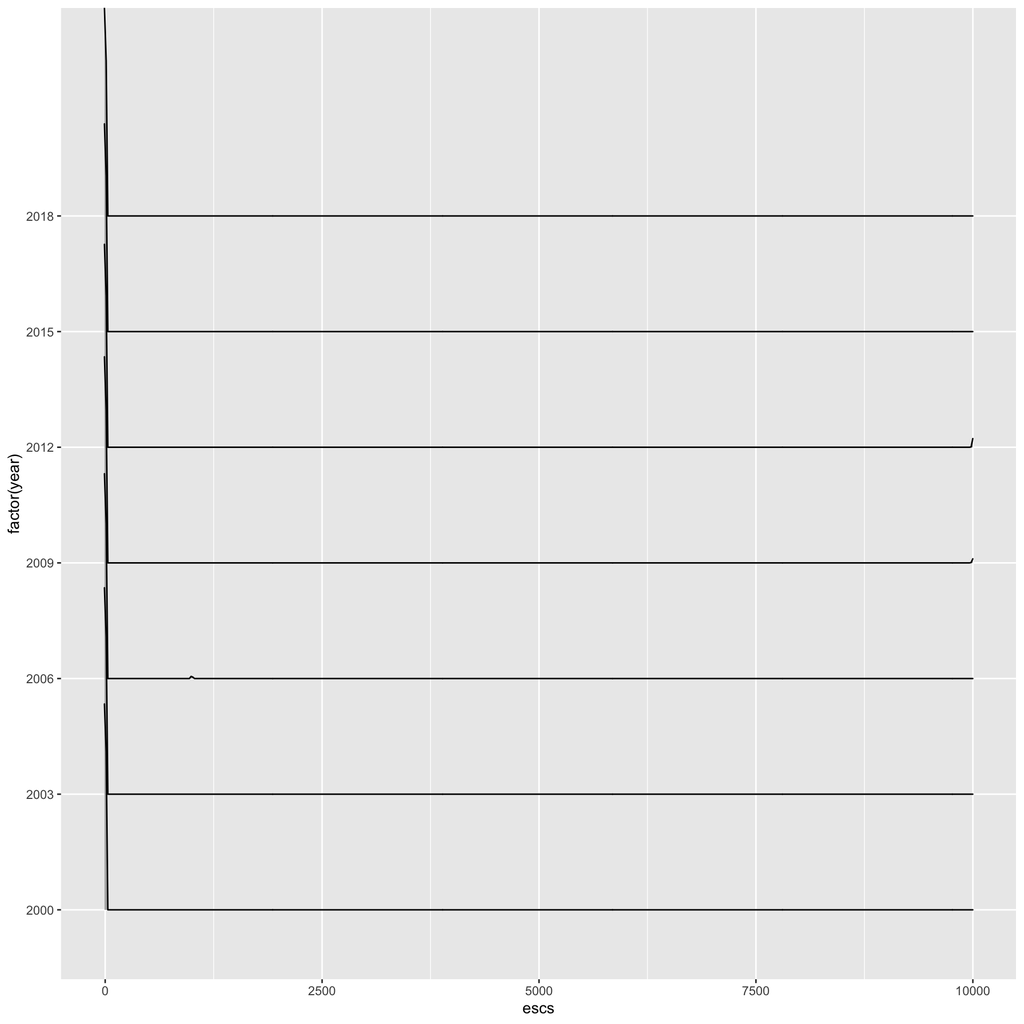

```r
student %>%
  ggplot(aes(x = escs, y = factor(year))) +
  geom_density_ridges()
```

```r
student %>%
  dplyr::filter(escs > 5) %>%
  group_by(year, escs) %>%
  tally()
```

```
## # A tibble: 5 x 3
## # Groups:   year [3]
##    year  escs     n
##   <int> <dbl> <int>
## 1  2006   997  1802
## 2  2006   999  2111
## 3  2009  9997  2426
## 4  2009  9999  3777
## 5  2012  9999 11791
```

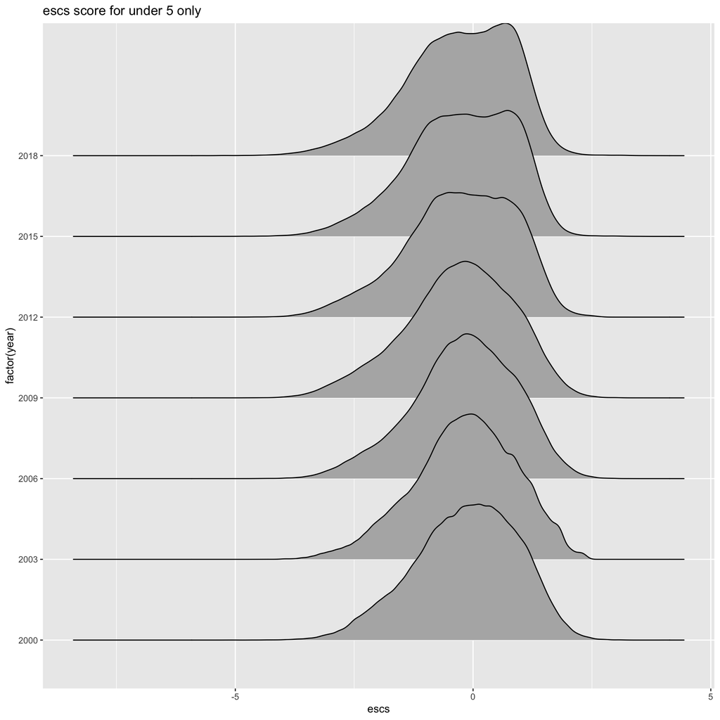

```r
student %>%
  dplyr::filter(escs < 5) %>%
  ggplot(aes(x = escs, y = factor(year))) +
  geom_density_ridges() +
  labs(title = "escs score for under 5 only")
```